# Crowned Eagles Nesting in the Urban Setting

Jacob Wyco

2023-09-12

Data analysis of Crowned Eagles breeding in Urban Environments.

Crowned Eagles are apex avian predators that are able to breed in an urban environment. This dataset was collected from South Africa and investigates how much urbanisation affects Crowned Eagle breeding.

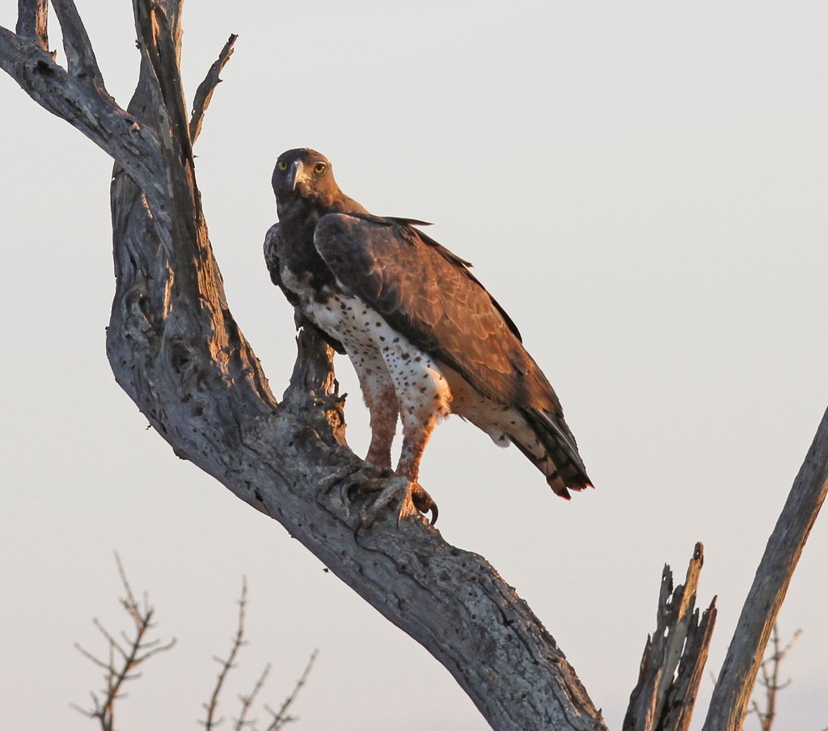

## Libraries and Data Set Up

N/A values were removed from dataset.

*Basic plot*

Plot depicting relationship between mass and urbanization. This is with the basic dataset.

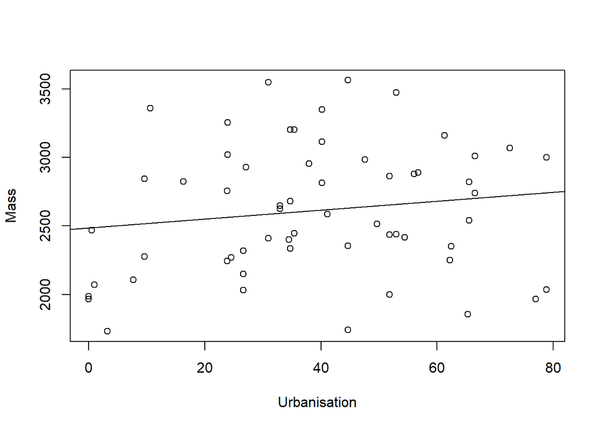

## Modeling and Plotting

*Linear Modeling*

ANOVA analyses of Mass ~ Urbanisation and Mass ~ P8tot, or the length of primary feather 8 in mm. This is investigating whether there is any significant differences between mass and urbanisation/P8tot.

```r
model_2 <- lm(Mass ~ Urbanisation, data = chick)
anova(model_2)
```

|  | Df | Sum Sq | Mean Sq | F value | Pr(>F) |
| --- | --- | --- | --- | --- | --- |
| Urbanisation | 1 | 284902.7 | 284902.7 | 1.300181 | 0.258867 |
| Residuals | 58 | 12709272.7 | 219125.4 | NA | NA |

```r
model_3 <- lm(Mass ~ P8tot, data = chick)
anova(model_3)
```

|  | Df | Sum Sq | Mean Sq | F value | Pr(>F) |
| --- | --- | --- | --- | --- | --- |
| P8tot | 1 | 2353804 | 2353804.2 | 12.83044 | 0.0006985002 |
| Residuals | 58 | 10640371 | 183454.7 | NA | NA |

[T-test of eagle chick mass and sex.]

```r
t.test(Mass ~ Sex, data = chick)
```

```
##
##  Welch Two Sample t-test
##
## data:  Mass by Sex
## t = -8.9291, df = 52.334, p-value = 4.225e-12
## alternative hypothesis: true difference in means between group 1 and group 2 is not equal to 0
## 95 percent confidence interval:
##  -874.0447 -553.3214
## sample estimates:
## mean in group 1 mean in group 2
##        2280.281        2993.964
```

*Kables*

These are tables depicting both the regular dataset and the means and standard deviation of chick mass.

Table 1. A knitr kable displaying the first 15 sites in the data set.

| Site.ID | Year | Incubation.attempt. | Ringing.age..success. | t.1.attempt. | t.1.success. | Sex | P8tot | Mass | Chick.body.condition | Urbanisation |
| --- | --- | --- | --- | --- | --- | --- | --- | --- | --- | --- |
| C1 | 2014 | 1 | 1 | 0 | 0 | 1 | 172.0000 | 1965 | -256.85897 | 0.0269906 |
| C2 | 2016 | 1 | 1 | 1 | 0 | 1 | 187.0000 | 2440 | 171.71033 | 53.0031517 |
| C2 | 2014 | 1 | 1 | 0 | 0 | 2 | 194.2705 | 3475 | 530.98981 | 53.0031517 |
| C3 | 2013 | 1 | 1 | 1 | 0 | 1 | 235.0000 | 2250 | -166.86792 | 62.1683550 |
| C4 | 2016 | 1 | 1 | 1 | 1 | 2 | 215.0000 | 2815 | -193.17587 | 40.1709259 |
| C4 | 2014 | 1 | 1 | 1 | 1 | 2 | 207.0000 | 3350 | 366.58717 | 40.1709259 |
| C4 | 2013 | 1 | 1 | 0 | 0 | 2 | 208.0000 | 3115 | 128.49179 | 40.1709259 |
| C5 | 2012 | 1 | 1 | 1 | 1 | 2 | 264.0000 | 3010 | -149.84950 | 66.4952550 |
| C6 | 2016 | 1 | 1 | 0 | 0 | 2 | 180.0000 | 2955 | 55.16243 | 37.9499640 |
| C7 | 2017 | 1 | 0 | 0 | 0 | 2 | 210.0000 | 2740 | -252.69897 | 66.5436876 |
| C8 | 2014 | 1 | 0 | 1 | 0 | 2 | 220.0000 | 3070 | 46.34723 | 72.5461100 |
| C9 | 2016 | 1 | 1 | 1 | 0 | 1 | 215.0000 | 2515 | 160.03969 | 49.6892732 |
| C9 | 2014 | 1 | 0 | 1 | 1 | 2 | 214.0000 | 2516 | 160.03969 | 49.6892732 |
| C10 | 2017 | 1 | 1 | 0 | 0 | 1 | 230.0000 | 2275 | -126.39101 | 9.6524385 |
| C10 | 2015 | 1 | 1 | 0 | 0 | 2 | 205.0000 | 2845 | -132.22207 | 9.6524385 |
| C11 | 2014 | 0 | 0 | 1 | 1 | 1 | 220.0000 | 2400 | 29.56279 | 34.4635565 |
| C12 | 2015 | 0 | 0 | 1 | 1 | 1 | 19.5000 | 2470 | 720.18650 | 0.5710660 |
| C13 | 2016 | 1 | 1 | 1 | 0 | 2 | 150.0000 | 2585 | -221.97617 | 41.1500045 |
| C14 | 2012 | 0 | 0 | 1 | 1 | 2 | 180.0000 | 2880 | -19.83757 | 56.0212249 |
| C15 | 2015 | 1 | 1 | 1 | 1 | 2 | 211.0000 | 2930 | -65.79435 | 27.1187700 |

Table 2. A summary kable displaying the mean, and standard deviation Crowned Eagle nestling mass by year.

| Year | n | mean | sd |
| --- | --- | --- | --- |
| 2012 | 12 | 2546.6 | 478.2 |
| 2013 | 4 | 2360.0 | 567.8 |
| 2014 | 16 | 2773.8 | 407.8 |
| 2015 | 12 | 2742.1 | 520.7 |
| 2016 | 7 | 2432.1 | 436.5 |
| 2017 | 9 | 2498.9 | 450.3 |

*Figures*

Bar plot of eagle chick mean mass over time.

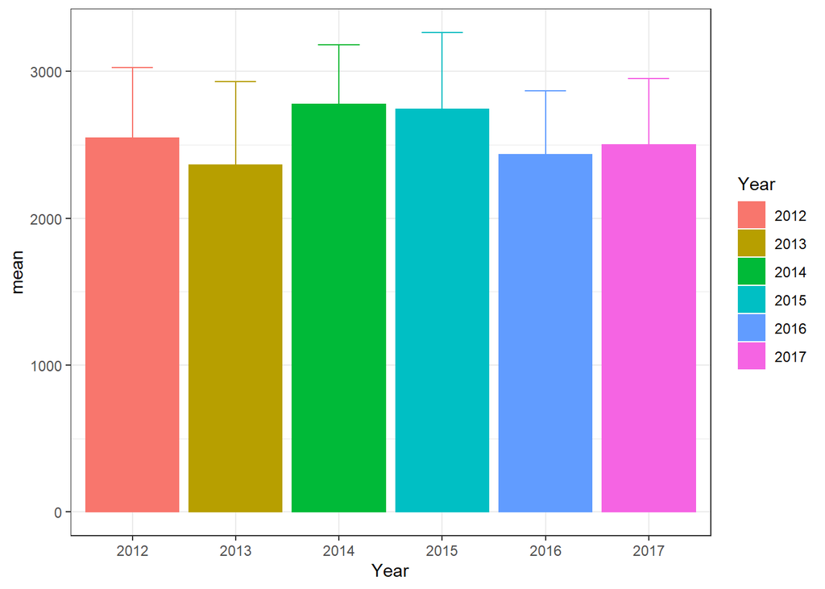

[Boxplot of chick mean mass over time.]

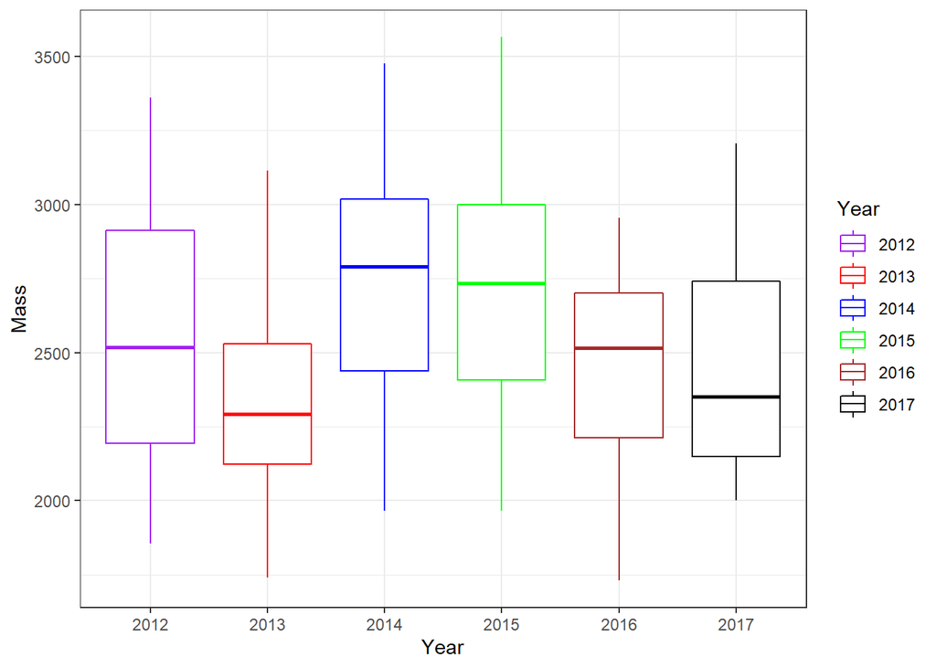

Lineplot showing relationship between mass and urbanisation over time.

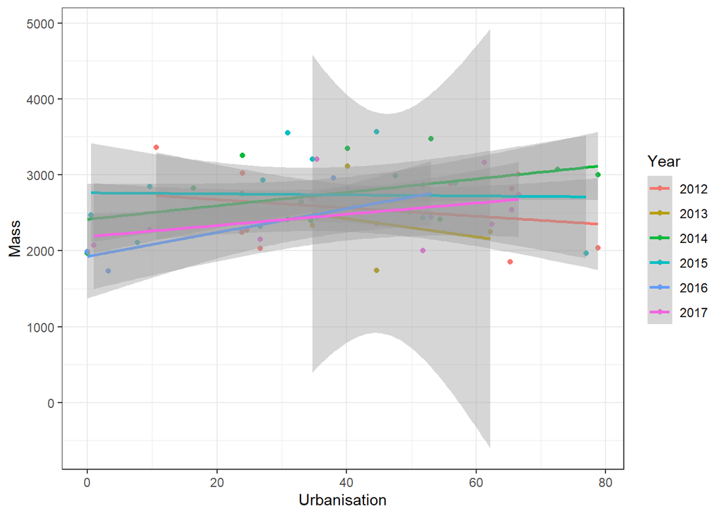

Static image from the web.

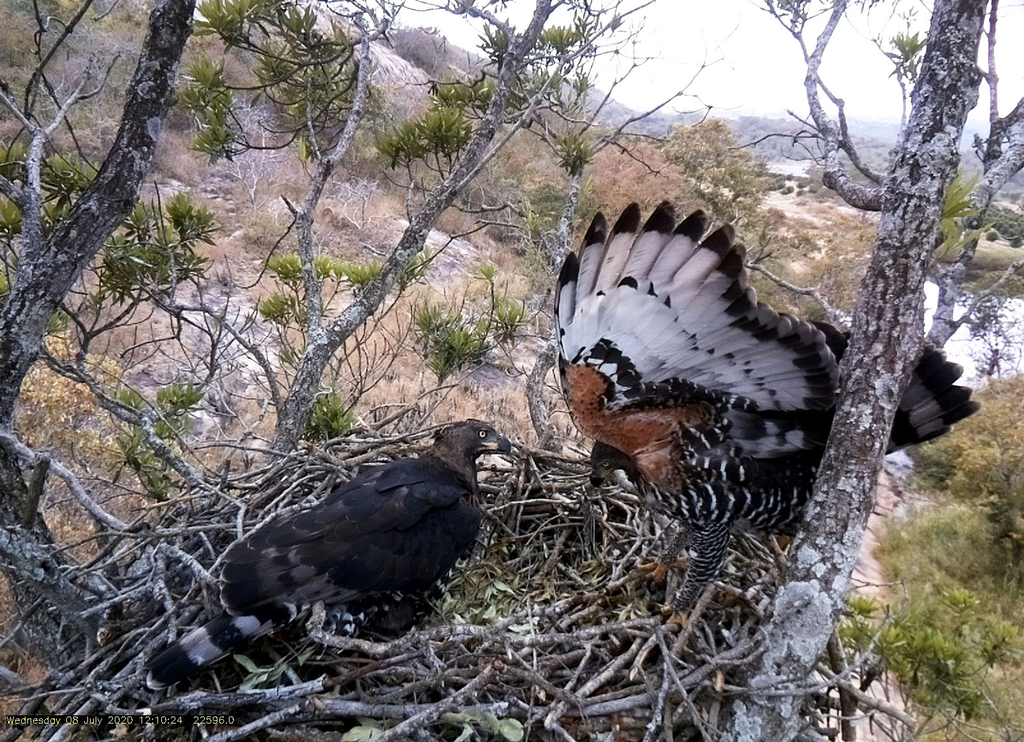

Figure 2. Nest of the Crowned Eagle (*Stephanoaetus coronatus*)

## Mapping and Video

Map of KwaZulu-Natal, location of the study. This is a region in South Africa were Crowned Eagles are found in urban settings.

```r
leaflet() %>%
  setView(lat = -28.652399, lng = 30.524356, zoom = 8) %>% #lat-long of the place of interest
  addTiles() %>%
  addMarkers(lat = -28.652399, lng = 30.524356, popup = "KwaZulu-Natal")
```

[interactive chart not shown]

Youtube video on urban Crowned Eagles.

[video not shown]

[I’m a link to the data source](https://datadryad.org/stash/dataset/doi:10.5061/dryad.kd51c5b30)